# 1. Random forest for email spam classifier

Your task for this question is to build a spam classifier using the UCR email spam dataset https://archive.ics.uci.edu/ml/datasets/Spambase. The collection of non-spam emails came from filed work and personal emails, and hence the word **"george"** and **"650"** are indicators of non-spam. These are useful when constructing a personalized spam filter.

## 1.1. Data characteristics

How many instances of spam versus regular emails are there in the data? How many data points are there? How many features are there?

Note: There may be some missing values. You can just fill in zero.

- Number of spam emails: 1,813
- Number of non-spam emails: 2,788
- Number of data points: 4,601
- Number of features: 57

## 1.2. Classification tree

Build a classification tree model (also known as the CART model). In Python, this can be done using `sklearn.tree.DecisionTreeClassifier`. Report the tree models fitted similar to what is shown in the random forest lecture, page 16 (the tree plot). In Python, getting this plot can be done using `sklearn.tree.plot_tree` function.

Below is a tree fitted with a max depth of 3:

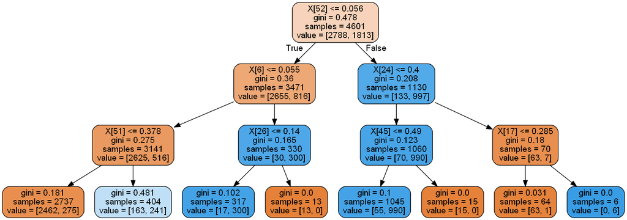

## 1.3. Random forest

Also build a random forest model. In Python, this can be done using `sklearn.ensemble.RandomForestClassifier`.

Now partition the data to use the first 80% for training and the remaining 20% for testing. Your task is to compare and report the AUC for your classification tree and random forest models on testing data, respectively. To report your results, please try different tree sizes. Plot the curve of AUC versus Tree Size, similar to page 15 of the lecture slides on random forest.

Below are the AUC scores for CART and random forest classifiers.

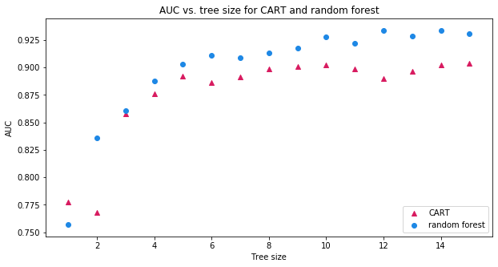

I observe that random forest generally performed better than CART with higher AUC scores.

# 2. Nonlinear regression and cross-validation

The coefficient of thermal expension $y$ changes with temperature $x$. An experiment to relate $y$ to $x$ was done. Temperature was measured in degrees Kelvin. (The Kelvin temperature is the Celsius temperature plus 273.15). The raw data file is `copper-new.txt`.

## 2.1. Linear regression

Perform linear regression on the data. Report the fitted model and the fitting error.

The fitted model is $\hat{y} = 0.0200x + 7.9017$ with a mean squared error of **16.8237** for the test set (20% of the data).

## 2.2. Nonlinear regression

Perform nonlinear regression with polynomial regression function up to degree $n = 10$ and use ridge regression (see lecture slides for bias-variance tradeoff). Write down your formulation and strategy for doing this and the form of the ridge regression.

My strategy:

1. For each degree $d$ from 1 to 10:
   1. Apply `PolynomialFeatures` to add polynomial features $1 \dots d$
   2. Fit a linear regression model on the 80% training data
   3. Generate predictions on the 20% test data
   4. Calculate MSE of the model on the 20% test data (comparing predicted vs. actual)
2. Identify the degree with the lowest test MSE in linear regression
3. Fit a ridge regression model on the training set using that degree

The lowest test MSE was 0.0862 with a degree of 5. The form of this ridge regression model would be:

$$ \hat{y} = \theta_1x + \theta_2 x^2 + \theta_3 x^3 + \theta_4 x^4 + \theta_5 x^5 + \theta_0, $$

where the parameter $\theta$ is learned by minimizing the regularized mean squared error:

$$ \frac{1}{m} \sum_{i=1}^{m} (y^{(i)}-\theta^\top x^{(i)})^2 + \lambda \lVert \theta \rVert_2^2 $$

## 2.3. 5-fold cross-validation

Use 5-fold cross-validation to select the optimal regularization parameter $\lambda$. Plot the cross-validation curve and report the optimal $\lambda$.

My method:

- Specify a parameter grid for `Ridge`'s `alpha` (our $\lambda$ regularization parameter), covering values from 0.1 to 10 in steps of 0.1
- Use `GridSearchCV` with the specified parameter grid, specifying mean squared error as the scoring metric for 5-fold cross-validation

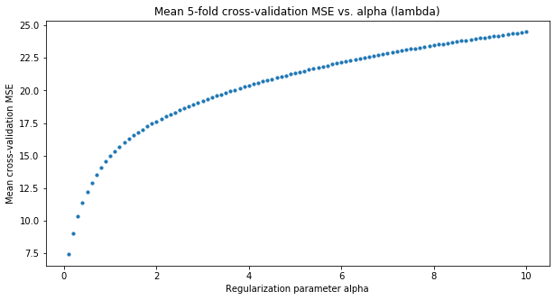

In my cross-validation trial, the optimal $\lambda$ was **0.1** with a MSE of 7.4228.

## 2.4. Prediction

Predict the coefficient at 400 degree Kelvin using both models. Comment on how you would compare the accuracy of predictions.

Predictions for each model are below.

- Linear regression: 15.9037
- Polynomial ridge regression: 16.6526

To compare the accuracy of a point prediction at 400 K, I would first determine the actual value of $y$ at 400 K using one of the following methods:

1. Heat a new copper sample to 400 K and measure its coefficient of thermal expansion $y$
2. Find a point at or close to 400 K in the dataset and take its coefficient $y$
3. If no such point is available, find points above and below 400 K, take their coefficients $y$, and interpolate to impute an "actual" value for $y$

I would then compare the distance between my "actual" $y$ and predicted $y$ values; whichever is closer would be judged more accurate.

To compare accuracy of models in general, I would:

1. Predict $y$ for the entire test set (20% of the original dataset)
2. Calculate MSE for the test set using the predicted $y$ vs. actual $y$

I would then judge the model with the lower MSE to be more accurate.

# 3. Regression and bias-variance tradeoff

Consider a dataset with $n$ data points $(x_i, y_i), x_i \in \mathbb{R}^p$, drawn from the following linear model:

$$ y = x^\top \beta^* + \epsilon, $$

where $\epsilon$ is Gaussian noise and the star sign $*$ is used to differentiate the true parameter from the estimators that will be introduced later. Consider regularized linear regression as follows:

$$ \hat{\beta}(\lambda) = \underset{\beta}{argmin} \left\{ \frac{1}{n} \sum_{i=1}^{n} (y_i - x_i^\top \beta)^2 + \lambda \lVert \beta \rVert_2^2 \right\}, $$

where $\lambda \geq 0$ is the regularization parameter. Let $X \in \mathbb{R}^{n \times p}$ denote the matrix obtained by stacking $x_i^\top$ in each row.

## 3.1. Closed form solution

Find the closed form solution for $\hat{\beta}(\lambda)$ and its distribution.

$$\begin{align} \hat{\beta}(\lambda) &= \underset{\beta}{argmin} \left\{ \frac{1}{n} \sum_{i=1}^{n} (y_i - x_i^\top \beta)^2 + \lambda \lVert \beta \rVert_2^2 \right\} \\ \end{align}$$

To minimize the expression, take the gradient with respect to $\beta$ and set it to 0:

$$\begin{align} \frac{\partial}{\partial \beta} \left[ \frac{1}{n} \sum_{i=1}^{n} (y_i - x_i^\top \beta)^2 + \lambda \lVert \beta \rVert_2^2 \right] &= \frac{1}{n} \frac{\partial}{\partial \beta} \left[ (y - X \beta)^\top(y - X \beta) + \lambda \lVert \beta \rVert_2^2 \right] \\ &= \frac{1}{n} \frac{\partial}{\partial \beta} \left[ y^\top y + \beta^\top X^\top X\beta - 2y^\top X\beta + \lambda \lVert \beta \rVert_2^2 \right] \\ &= \frac{1}{n} \left[ 2X^\top X\beta - 2X^\top y + 2\lambda\beta \right] \\ &= -\frac{2}{n} X^\top y + \frac{2}{n} X^\top X \beta + \frac{2}{n} \lambda\beta \end{align}$$

Setting to 0 and solving:

$$\begin{align} -\frac{2}{n} X^\top y + \frac{2}{n} X^\top X \beta + \frac{2}{n} \lambda\beta &= 0 \\ X^\top X \beta + \lambda\beta &= X^\top y \\ (X^\top X + \lambda I)\beta &= X^\top y \\ \beta &= (X^\top X + \lambda I)^{-1} X^\top y \end{align}$$

Therefore, the closed form solution is $\color{blue}{\hat{\beta}(\lambda) = (X^\top X + \lambda I)^{-1}X^\top y}$. The estimator is assumed to have a Gaussian distribution, which is characterized by the mean and variance.

The mean and variance of the estimator are: $$\begin{align} E[\hat{\beta}] &= (X^\top X + \lambda I)^{-1}X^\top X\beta^* \\ Var[\hat{\beta}] &= \sigma^2 (X^\top X + \lambda I)^{-1} X^\top X \left[(X^\top X + \lambda I)^{-1}\right]^\top \end{align}$$

Therefore, the distribution of $\color{blue}{\hat{\beta} \sim N\left[(X^\top X + \lambda I)^{-1}X^\top X\beta^*, \sigma^2 (X^\top X + \lambda I)^{-1} X^\top X \left[(X^\top X + \lambda I)^{-1}\right]^\top\right]}$.

Derivation for the expected value (mean):

$$\begin{align} E[\hat{\beta}] &= E\left[ (X^\top X + \lambda I)^{-1}X^\top y \right] \\ &= E\left[ (X^\top X + \lambda I)^{-1}X^\top (X\beta^* + \epsilon ) \right] \end{align}$$

In a regression model, the expected value of noise is zero: $E[\epsilon] = 0$. Therefore:

$$\begin{align} E[\hat{\beta}] = (X^\top X + \lambda I)^{-1}X^\top(X\beta^* + 0) = (X^\top X + \lambda I)^{-1}X^\top X\beta^* \end{align}$$

## 3.2. Bias

Calculate the bias $E\left[x^\top \hat{\beta}(\lambda)\right] - x^\top \beta^*$ as a function of $\lambda$ and some fixed test point $x$.

Given $\hat{\beta} = (X^\top X + \lambda I)^{-1}X^\top y$ from part 3.1:

$$\begin{align} E\left[x^\top \hat{\beta}(\lambda)\right] - x^\top \beta^* &= E\left[x^\top (X^\top X + \lambda I)^{-1}X^\top y\right] - x^\top \beta^* \\ &= x^\top (X^\top X + \lambda I)^{-1}X^\top X \beta^* - x^\top \beta^* \\ &= x^\top (X^\top X + \lambda I)^{-1}X^\top X \beta^* - x^\top \left[ (X^\top X + \lambda I)^{-1} (X^\top X + \lambda I) \right] \beta^* \\ &= x^\top (X^\top X + \lambda I)^{-1} \beta^* \left[X^\top X - (X^\top X + \lambda I \right)] \\ &= x^\top (X^\top X + \lambda I)^{-1} \beta^* (-\lambda I) \\ &= \color{blue}{-\lambda x^\top (X^\top X + \lambda I)^{-1} \beta^*} \end{align}$$

## 3.3. Variance

Calculate the variance term $E\left[\left(x^\top \hat{\beta}(\lambda) - E[x^\top \hat{\beta}(\lambda)] \right)^2 \right]$.

$$\begin{align} E\left[\left(x^\top \hat{\beta}(\lambda) - E[x^\top \hat{\beta}(\lambda)] \right)^2 \right] &= Var[x^\top \hat{\beta}] \\ &= x^\top Var[\hat{\beta}] x \\ &= \color{blue}{\sigma^2 x^\top (X^\top X + \lambda I)^{-1} X^\top X \left[(X^\top X + \lambda I)^{-1}\right]^\top x} \end{align}$$

## 3.4. Impact of $\lambda$ on squared error

Use the results from parts (b) and (c) and the bias-variance decomposition to analyze the impact of $\lambda$ on the squared error. Specifically, which term dominates when $\lambda$ is small, and large, respectively?

Hint: Properties of an affine transformation of a Gaussian random variable will be useful throughout this problem.

The expected loss (squared error) is $\color{blue}{\text{bias}^2} + \color{red}{\text{variance}} + \text{noise}$. Using parts 3.2 and 3.3:

$$\begin{align} \text{squared error} &= \color{blue}{-\lambda x^\top (X^\top X + \lambda I)^{-1} \beta^*} + \color{red}{\sigma^2 x^\top (X^\top X + \lambda I)^{-1} X^\top X \left[(X^\top X + \lambda I)^{-1}\right]^\top x} + \text{noise} \end{align}$$

**If $\lambda$ is large**, then the first term becomes very large due to the presence of the scalar $-\lambda$ (which gets squared). This means that **the first term ($\text{bias}^2$) dominates**. Similarly, due to the presence of $\lambda$ in an inverted matrix $(X^\top X + \lambda I)^{-1}$ in the second term, a large $\lambda$ will cause the values in the matrix to become very small, making the second term less dominant.

**If $\lambda$ is small**, the presence of the scalar squared in the first term will make it less dominant. On the other hand, the presence of $\lambda$ in the inverted matrix will have the opposite effect on the second term making it larger. This means that **the second term ($\text{variance}$) dominates**.